# Use of For Loops

Daniel Schiff

March 22, 2022

## The Importance of For Loops

In almost everything we do, we see repetition resulting in the development of stable routines and production. For example, Henry Ford was able to find reproducibility in the assembly line. Manufacturing car after car the same way to improve cost, and efficiency. Like Ford’s method, modern computers can repeat a process over and over again with accuracy and exactness based on the information (code) it is fed. In fact, this is one of the great advantages of computing machines.

In R, we have a several functions that will do tasks repeatedly while some condition(s) are met.

- **while loops**, which do something *while* a statement or group of statements are true.
- **repeat loops**, which will continue to do something until it is told to not continue. If it is never told not to continue, it will keep running infinitely.
- **for loops**, which do something while going through values of a sequence or list that is fed to it. We’ll look at this loop in detail since it is so commonly used.

We develop an example of how to use a *for loop* for calculating probabilities when sampling without replacement. Suppose we have 100 Skittles, and we know that 3 would kill you if you ate them, while the other 97 are 100% safe.

The question we want to find out is, given you have eaten a certain number of Skittles already, *what is the chance that you’ll remain alive after eating the next Skittle*.

The first time you eat one of the Skittles, you have a 97 out of 100 chance of staying alive (97%). The odds of staying alive will go down, as you eat more Skittles (sampling without replacement). By the time you eat the 31st Skittle, the probability that the next Skittle won’t kill you is only 25%.

> In the jargon of probability theory, we are simulating a [**geometric distribution**](https://en.wikipedia.org/wiki/Geometric_distribution), which can be thought of as the probability distribution of the number of successes (staying alive) before experiencing a failure (dying)

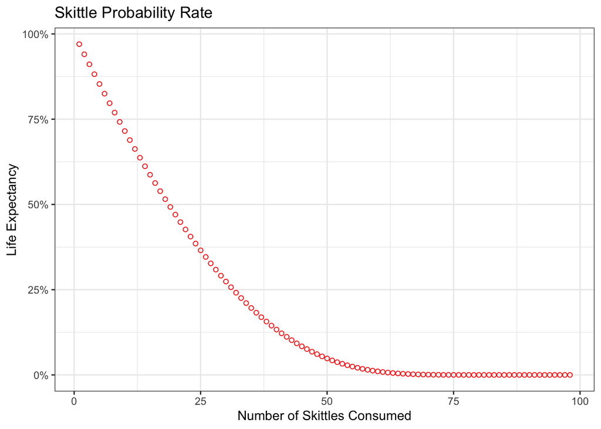

```r
require(tidyverse)
# Set p to NA
p <- NA
# Set a numerator
n <- 0
# Set Denominator
d <- 3
# Set an empty data frame
output <- NA

e <- 1
# expected life value, if you eat no skittles 100% chance of living or 1

# Write a for loop to produce probability that they will not kill you
for (i in 98:1) {
  # make the values into a vector
  out <- data.frame(i, n, d, p, e)
  # Add one to the numerator
  n <- n + 1
  # Add one to the denominator
  d <- d + 1
  # combine the vector into the data frame
  output <- rbind(output, out) %>%
    mutate(p = n / d, e = e * p) %>%
    drop_na(p) # drop if there are a null vector
}

# Include a Graphic

g <- ggplot(output, aes(x = i, y = e)) +
  geom_point(shape = 1, color = "red") +
  xlab("Number of Skittles Consumed") +
  ylab("Life Expectancy") +
  scale_y_continuous(labels = scales::percent_format()) +
  theme_bw() +
  labs(title = "Skittle Probability Rate")

g
```

## Lets look more into for loops

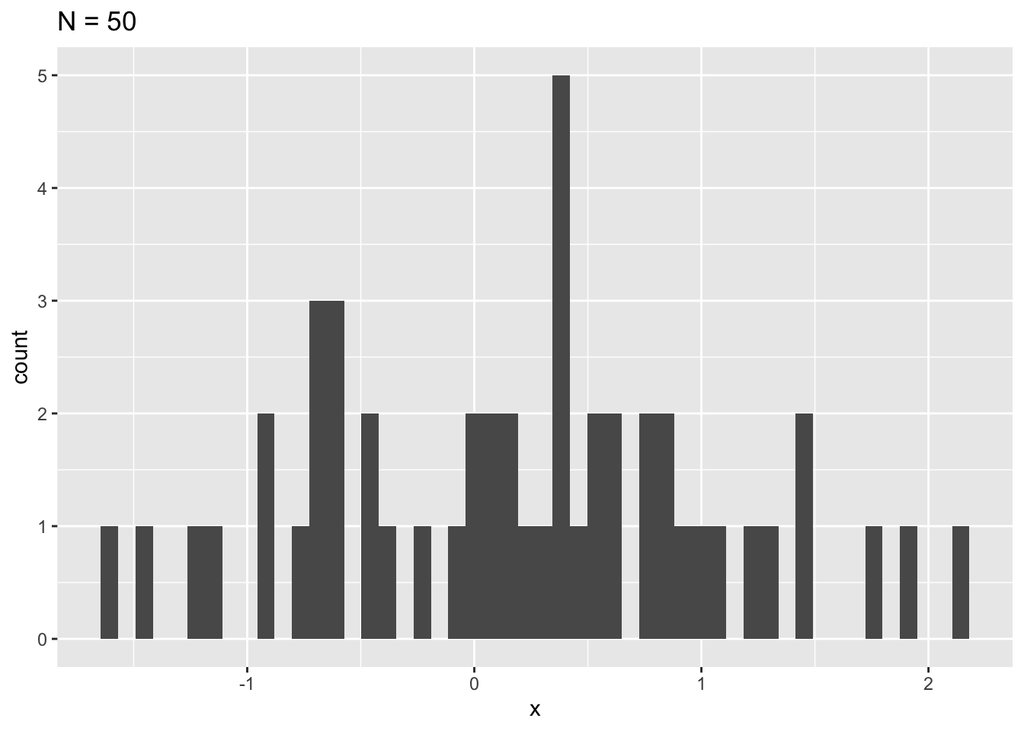

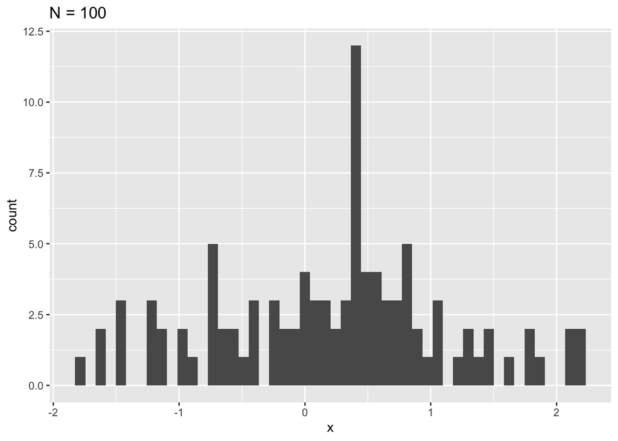

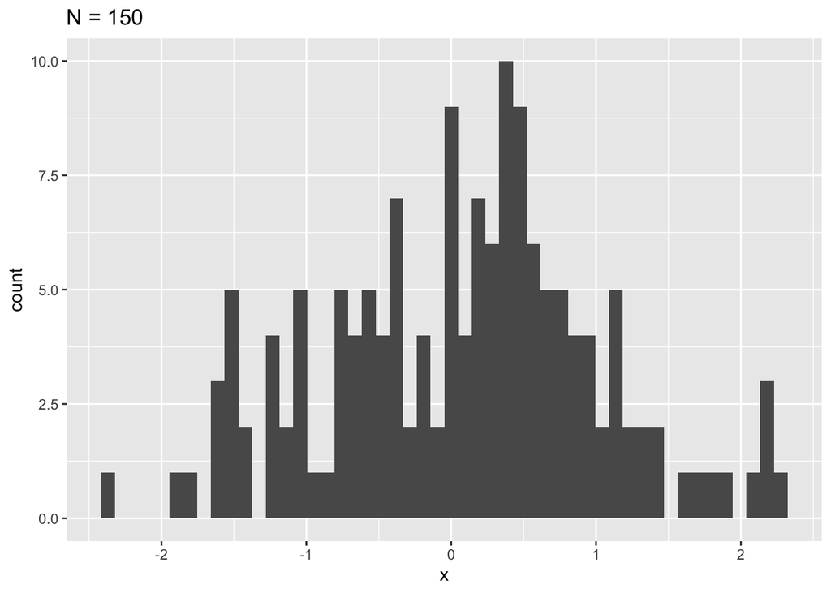

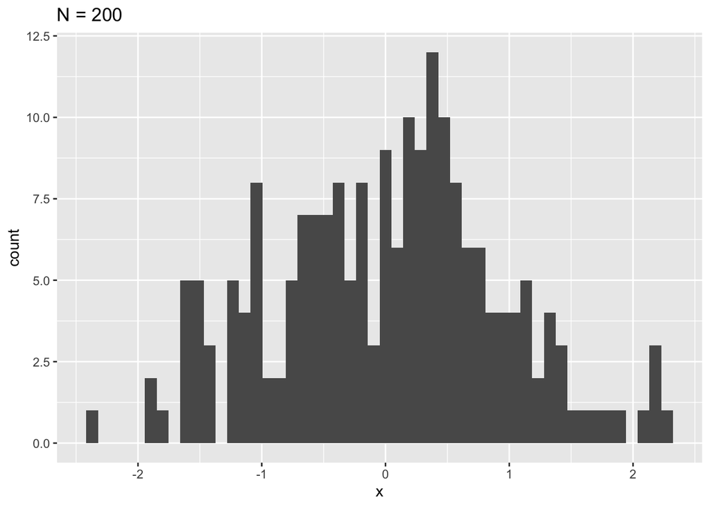

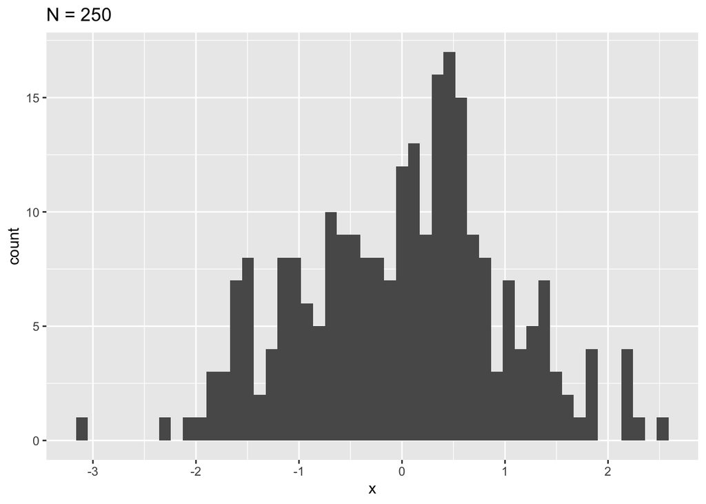

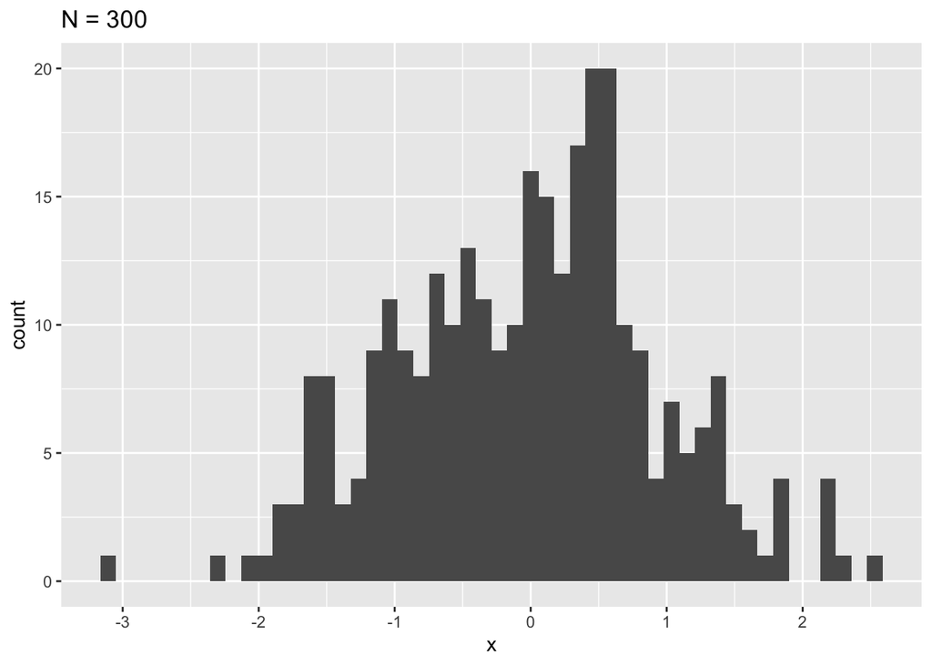

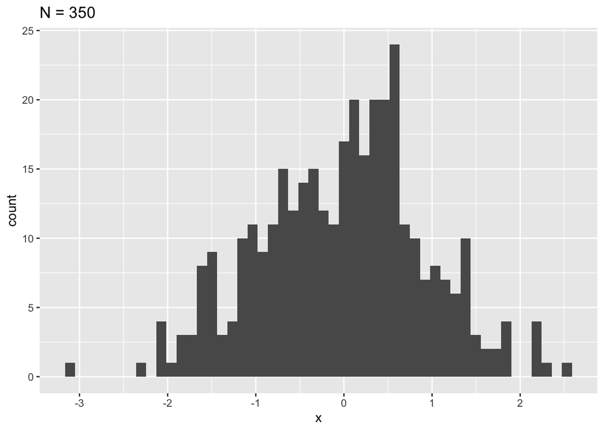

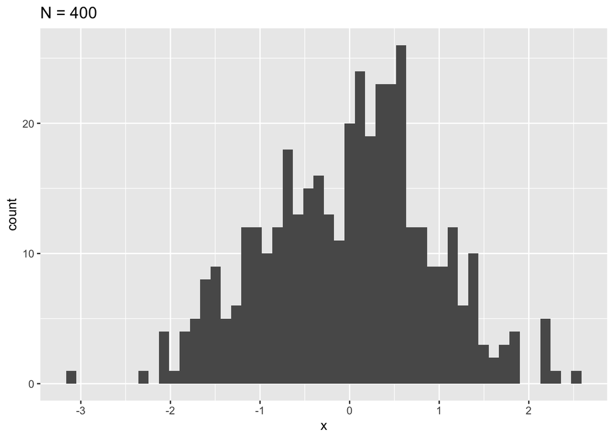

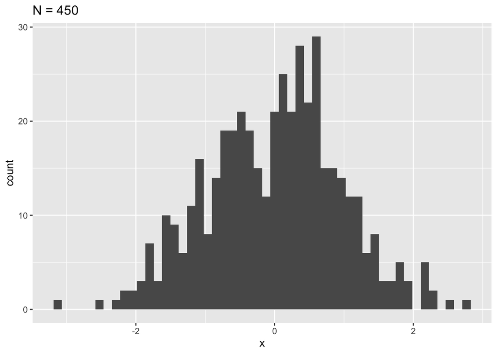

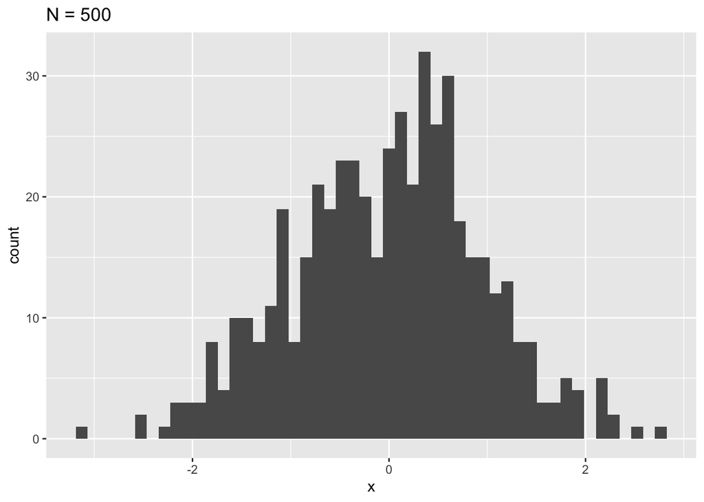

```r
for (m in seq(50, 500, 50)) {

  # Set the seed for standard sampling
  set.seed(435)

  # Sample a random normal distribuition
  x <- rnorm(n = m, mean = 0, sd = 1)
  x <- data.frame(x)

  p <- ggplot(x, aes(x)) +
    geom_histogram(bins = 50) +
    labs(title = paste0("N = ", m))

  print(p)
}
```

## We Can Loop For Categorical or Factor Data

When looking at loops, at first numbers come to mind. However, *for loops* can be run on any arbitray **list** of objects. These could be a list of data.frame objects, a list of models, or a list of words. In the following loop, we look at the `species` variable in the iris data set. We do a complex loop of group_by() and summarize() as seen in the bit of code below it. The idea is to show how a list of words derived from your data can be used in a for loop.

```r
outputiris <- list() # create an empty list

for (sp in levels(iris$Species)) {
  print(sp)
  # I am just kidding lets take it to the next step

  # Lets group by using a filter to filter the type of species we would want
  outiris <- filter(iris, Species == sp) %>%
    # Lets set the means
    summarise(
      Species = sp, slMean = mean(Sepal.Length), swMean = mean(Sepal.Width),
      plMean = mean(Petal.Length), pwMean = mean(Petal.Width)
    )
  outputiris[[sp]] <- outiris # Save the result into the list, which is now a named list
}
```

```
## [1] "setosa"
## [1] "versicolor"
## [1] "virginica"
```

```r
outputiris <- bind_rows(outputiris, .id='Species')
print(outputiris)
```

```
##      Species slMean swMean plMean pwMean
## 1     setosa  5.006  3.428  1.462  0.246
## 2 versicolor  5.936  2.770  4.260  1.326
## 3  virginica  6.588  2.974  5.552  2.026
```

There is an easier and quicker way to do this, but the previous example was meant to show how we *can* do it using for loops.

```r
 iris %>%
  group_by(Species) %>%
  summarise(
    slMean = mean(Sepal.Length), swMean = mean(Sepal.Width),
    plMean = mean(Petal.Length), pwMean = mean(Petal.Width)
  )
```

```
## # A tibble: 3 × 5
##   Species    slMean swMean plMean pwMean
##   <fct>       <dbl>  <dbl>  <dbl>  <dbl>
## 1 setosa       5.01   3.43   1.46  0.246
## 2 versicolor   5.94   2.77   4.26  1.33
## 3 virginica    6.59   2.97   5.55  2.03
```